# Social Network Analysis - Final Assignment

Sohamjit Mukherjee

15 March 2019

# Overview

The source of the data can be found through the following link: http://networkdata.ics.uci.edu/netdata/html/floridaFoodWebs.html

The data consists of networks of carbon exchange as they normally occur in the ecosystem of South Florida. Separate networks for wet and dry seasons are present for the ecosystems of the cypress wetlands, the Everglades gramminoid marshes, the mangrove estuaries, and the shallows of Florida Bay. Vertices in these networks represent major components of the ecosystem, and edges represent the tranfers of material or energy between the components.

Some animals overpopulate certain regions of the world whereas other species are endangered in others. This causes threat for our environment and ecosystem. It is a well known fact that Florida suffers from an overpopulation of alligators and snakes. Nevertheless, the approaches taken to control overpopulations focus on killing, catching or poisoning the overpopulated species. The measures taken to save endangered species have a rather limited scope as well. NGOs and governments often do not have the tools and resources to engage in an in-depth analysis. This project will help governments, NGOs and other organizations to understand the roles of certain animals within an ecosystem through the eyes of a Social Network Analysis. The goal is make the previously mentioned groups aware of the key issues in order to develop customized measures to combat overpopulation as well as help endangered species. We want to provide a kind of interactive platform that can be updated with current data.

For our analysis, we will start with the Cypress Wetlands area of the south Florida region and try to compare how the carbon exchange between dry and wet season changes. Moreover, we will analyze the interactions among the different animals. It deserves to mention that our overall analysis will focus on interactions of animals.

In this Rmarkdown file,

All the insights & findings have been written in blue

All the technical comments have been made in orange

## Loading the Packages

Let us start by clearing the workspace and installing the required libraries. “SuppressMessages” in the code helps us to not display the unnecessary messages during the installation process.

## Load the Dataset

Load the original dataset. The .Rdata file needs to be in the same location as that of the this Rmarkdown file. The data can be downloaded from this location : http://networkdata.ics.uci.edu/netdata/html/floridaFoodWebs.html

```r
load("floridaFoodWebs.Rdata")
```

### Data Type Conversion From Network to Igraph data type

Now, the dataset we loaded is of the data type “network”. We will convert this data type into “igraph” format. For doing this we will use the library intergraph.

```r
CypDry = asIgraph(cypDry)
CypWet = asIgraph(cypWet)
```

As previously mentioned we will for now only work with the data set Cypress Wetlands (dry and wet season).

## Exploratory Data Analysis

### Overall Summary

Let us quickly get an overview of both of the networks.

```r
print(cypDry)
```

```
##  Network attributes:
##   vertices = 71
##   directed = TRUE
##   hyper = FALSE
##   loops = FALSE
##   multiple = FALSE
##   title = South Florida Food Webs: Cypress Wetlands Dry Season
##   total edges= 640
##     missing edges= 0
##     non-missing edges= 640
##
##  Vertex attribute names:
##     bio-masses./.cypdry.dat ECO.type vertex.names
##
##  Edge attribute names:
##     cypdry.dat1
```

```r
print(cypWet)
```

```
##  Network attributes:
##   vertices = 71
##   directed = TRUE
##   hyper = FALSE
##   loops = FALSE
##   multiple = FALSE
##   title = South Florida Food Webs: Cypress Wetlands Wet Season
##   total edges= 631
##     missing edges= 0
##     non-missing edges= 631
##
##  Vertex attribute names:
##     bio-masses./.cypwet.dat ECO.type vertex.names
##
##  Edge attribute names:
##     cypwet.dat1
```

A quick overview of the datasets provides us with the following information :

We would like to provide some background information related to the terms “dry season” and “wet season”. The “wet season” mainly refers to the period from May through October and is characterized by high temperatures (>30 Celsius)/humidity. Besides, this season produces the majority of the region’s average rainfall. The so called “dry season” runs from December to mid-May and is characterized by low humidity levels and temperatures between 10-25 Celsius. It deserves to mention that around 20% of the region’s average annual rain falls during this time of the year.

In the following paragraphs we will provide some dataset specific information. For example, we can conclude that there are a total 71 vertices (71 different animals) in the wet and dry seasons.

The graph is a directed one without any loops. There are a total of 640 edges in the dry season wherease the number of edges reduces to 631 during wet season. There are no missing edges in both seasons.

### Plot Overall Dataset - An Interactive Visualization with VisNetwork

We will use the “visnetwork” library to plot and get an idea of the overall network. This is an interactive graph and will consume a lot of memory. In case the memory of the computer is not sufficient, the computer might not be able to generate the HTML file. In that case, our advice will be to run the code chunk sepearetely in the Rmarkdown file.

```r
# Preparing the node data frame by extracting names and groups from the graph

nodes <- data.frame(id = V(CypDry)$vertex.names ,title = V(CypDry)$vertex.names, group = V(CypDry)$ECO.type)
nodes <- nodes[order(nodes$id, decreasing = T),]

# Creating nodes id

nodes$Seq = seq(nrow(nodes))

# Preparing the edge data frame by extracting the edges information from the data set

edges <- get.data.frame(CypDry, what="edges")[1:2]
edges$from =nodes$id[match(edges$from,nodes$Seq)]
edges$to =nodes$id[match(edges$to,nodes$Seq)]

# Plot the graph

visNetwork(nodes,edges , width = "100%", main = "Networks in the Cypress Wetlands Dry Season") %>%
  visOptions(highlightNearest = T, nodesIdSelection = T)%>%
  visGroups(groupname = "2", color = "red") %>%
  visLegend(useGroups = T, addNodes = data.frame(label = "Nodes", shape = "circle"),
            addEdges = data.frame(label = "link", color = "green")) %>%
  visEdges(shadow = TRUE,
           arrows =list(to = list(enabled = TRUE, scaleFactor = 2)),
           color = list(color = "lightgreen", highlight = "red"))
```

[interactive chart not shown]

The above shown graph provides us with a general overview of the networks in the Cypress Wetlands Dry Season. The 5 different colors represent the 5 different groups (Blue: Living/producing compartment, Red: Other compartment, Green: Input, Light-red: Output, Yellow: Respiration ). The filter option (“detail-on-demand”) alllows us to have a closer look at some of the animals. This in turn shifts the scope from a broad perspective to a narrow one. For example, the applied filter for alligators illustrates the different connections of alligators. Nevertheless, at this stage we do not make the distinction between directed and undirected graphs. The overall purpose of this interactive visualization is to develop a thorough understanding for the networks of the different animals during the “Dry Season”. This approach is well in line with the general guidlines of an EDA.

```r
# Preparing the node data frame by extracting names and group from the graph

nodes <- data.frame(id = V(CypWet)$vertex.names ,title = V(CypWet)$vertex.names, group = V(CypWet)$ECO.type)
nodes <- nodes[order(nodes$id, decreasing = T),]

# Creating nodes id

nodes$Seq = seq(nrow(nodes))

# Preparing the edge data frame by extracting the edges information from the data set

edges <- get.data.frame(CypDry, what="edges")[1:2]
edges$from =nodes$id[match(edges$from,nodes$Seq)]
edges$to =nodes$id[match(edges$to,nodes$Seq)]

# Plot the graph

visNetwork(nodes,edges , width = "100%", main = "Networks in the Cypress Wetlands Dry Season") %>%
  visOptions(highlightNearest = T, nodesIdSelection = T)%>%
  visGroups(groupname = "2", color = "red") %>%
  visLegend(useGroups = T, addNodes = data.frame(label = "Nodes", shape = "circle"),
            addEdges = data.frame(label = "link", color = "green")) %>%
  visEdges(shadow = TRUE,
           arrows =list(to = list(enabled = TRUE, scaleFactor = 2)),
           color = list(color = "lightgreen", highlight = "red"))
```

[interactive chart not shown]

### Overall Degree Distribution

The degree disitribution gives us a good overview of the position of animals within the ecosystem. For example, who are the natural enemies of a specific species? We sticked to the following 3 steps in order to derive to our conlcusions:

1) Degree distribution with mode out (only for out degree) - Compare the animals whose out degree changes in between the wet and dry season. The out degree shows what kind of animals are predators. For example, the out degress of an alligator show the preferred food of alligators. 2) Degree distribution with mode in (only for in degree) - Compare the animals whose in degree changes in between the wet and dry seasons. Animals with many in degrees are in danger because they are the preferred food of many other predators. 3) Degree distribution with mode all (sum of both the in and out degrees)

#### Cypress Wetlands Dry & Wet Season Comparison - Out Degree

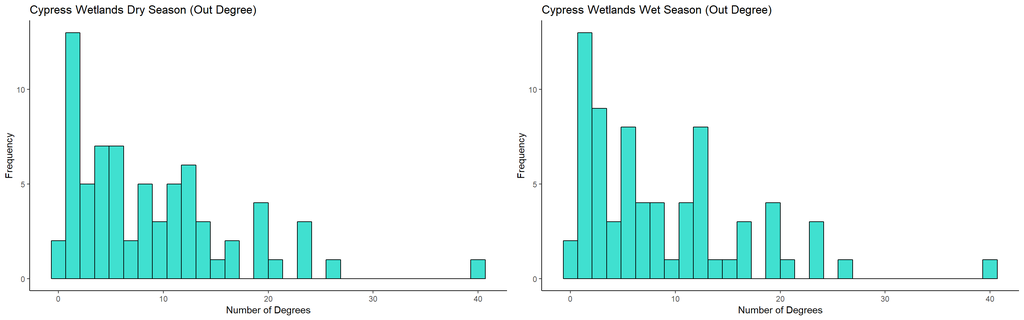

```r
# Calculate the out degree.

cypDry_Degree = as.data.table(degree(CypDry, mode = "out"))

cypWet_Degree = as.data.table(degree(CypWet, mode = "out"))

# Plot the degree distribution.

Plot1 = ggplot(data=cypDry_Degree, aes(cypDry_Degree$V1)) +
       geom_histogram(col = "black", fill= "turquoise") +
       theme_classic() +
       ggtitle("Cypress Wetlands Dry Season (Out Degree)")  +
        xlab("Number of Degrees") +
        ylab("Frequency")

Plot2 = ggplot(data=cypWet_Degree, aes(cypWet_Degree$V1)) +
       geom_histogram(col = "black", fill= "turquoise") +
       theme_classic() +
       ggtitle("Cypress Wetlands Wet Season (Out Degree)")  +
        xlab("Number of Degrees") +
        ylab("Frequency")

# Use the library fucntion grid arrange to compare the graphs side by side.

grid.arrange(Plot1, Plot2, nrow = 1)
```

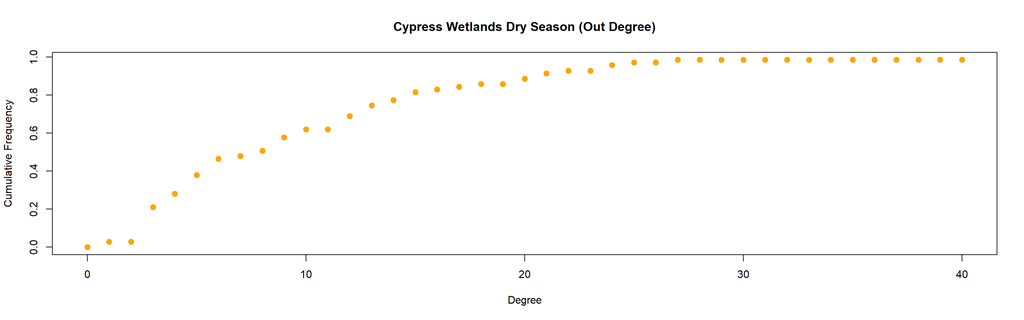

```r
# Lets also see how the cumulative distribution looks like.

Deg_Dist_Dry = degree_distribution(CypDry, cumulative=T, mode="out")

Plot3 = plot( x=0:max(cypDry_Degree), y=1-Deg_Dist_Dry, pch=19, cex=1.2, col="orange", main ="Cypress Wetlands Dry Season (Out Degree)",
xlab="Degree", ylab="Cumulative Frequency")
```

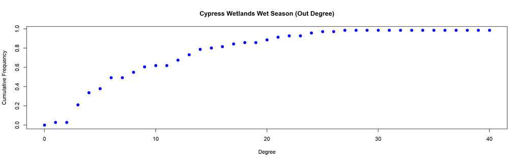

```r
Deg_Dist_Wet = degree_distribution(CypWet, cumulative=T, mode="out")

Plot4 = plot( x=0:max(cypWet_Degree), y=1-Deg_Dist_Wet, pch=19, cex=1.2, col="blue", main ="Cypress Wetlands Wet Season (Out Degree)",
xlab="Degree", ylab="Cumulative Frequency")
```

By comparing the out degrees in the wet and in the dry season, we can infer that the overall distribution has remained almost the same. However, there are some small differences which may not be explicitly visible to the bare eye.

We want to shed further light on the previously mentioned “small differences” and decided to compare only those animals that show a change in degree between the different seasons (wet and dry season).

```r
# Merge the out degree for wet and dry season together.

Df = cbind(cypWet_Degree , cypDry_Degree)

# Assign column names.
names(Df) = c("Out Degree - Wet Season", "Out Degree - Dry Season")

# Create one unique identifier.

Df$Identifier <- seq.int(nrow(Df))

# Extract only those rows where the degrees do not match in wet and dry season.

Df = Df[which(Df[,1]!=Df[,2])]

Df = cbind(vertex_attr(CypWet, name="vertex.names", index =Df$Identifier) , Df[,1], Df[,2])

names(Df) = c("Animals", "Out Degree - Wet Season", "Out Degree - Dry Season")

Df
```

```
##                  Animals Out Degree - Wet Season Out Degree - Dry Season
##  1:           Alligators                      11                       8
##  2:              Turtles                      11                       9
##  3:               Snakes                      16                      14
##  4:               S Frog                      15                      14
##  5:             Salam. L                       7                       4
##  6:             Tadpoles                       8                       6
##  7:         Anseriformes                       7                       2
##  8:          Galliformes                       9                      11
##  9:               Egrets                       5                       9
## 10:             GB Heron                       3                       5
## 11:         Other Herons                       3                      11
## 12:           Wood stork                       2                       8
## 13:           White ibis                       7                       9
## 14:           Gruiformes                       3                       4
## 15:     Caprimulgiformes                       4                       3
## 16:          Woodpeckers                       5                       4
## 17: Passeriformes onniv.                      14                      15
## 18:  Passeriformes pred.                      13                      14
## 19:               Shrews                       5                       7
## 20:                 Mink                       3                       4
## 21:              Rabbits                      13                      11
## 22:            Armadillo                       3                       4
##                  Animals Out Degree - Wet Season Out Degree - Dry Season
```

The above is the list of only those animals that changed their out degrees between the Dry and Wet season.

#### Cypress Wetlands Dry & Wet Season Comparison - In Degree

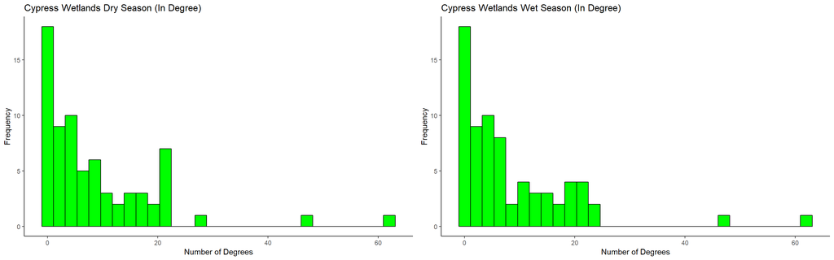

```r
# Calculate the out degree.

cypDry_Degree = as.data.table(degree(CypDry, mode = "in"))

cypWet_Degree = as.data.table(degree(CypWet, mode = "in"))

# Plot the degree distribution.

Plot1 = ggplot(data=cypDry_Degree, aes(cypDry_Degree$V1)) +
       geom_histogram(col = "black", fill= "green") +
       theme_classic() +
       ggtitle("Cypress Wetlands Dry Season (In Degree)")  +
        xlab("Number of Degrees") +
        ylab("Frequency")

Plot2 = ggplot(data=cypWet_Degree, aes(cypWet_Degree$V1)) +
       geom_histogram(col = "black", fill= "green") +
       theme_classic() +
       ggtitle("Cypress Wetlands Wet Season (In Degree)")  +
        xlab("Number of Degrees") +
        ylab("Frequency")

# Use the library fucntion grid arrange to compare the graphs side by side.

grid.arrange(Plot1, Plot2, nrow = 1)
```

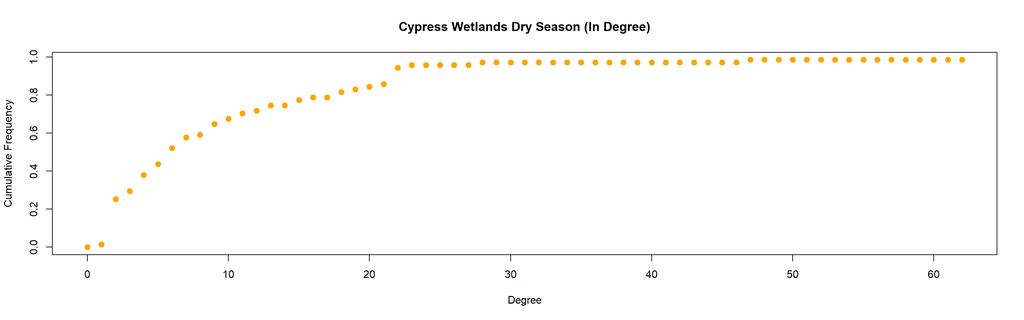

```r
# Lets also see how the cumulative distribution looks like.

Deg_Dist_Dry = degree_distribution(CypDry, cumulative=T, mode="in")

Plot3 = plot( x=0:max(cypDry_Degree), y=1-Deg_Dist_Dry, pch=19, cex=1.2, col="orange", main ="Cypress Wetlands Dry Season (In Degree)",
xlab="Degree", ylab="Cumulative Frequency")
```

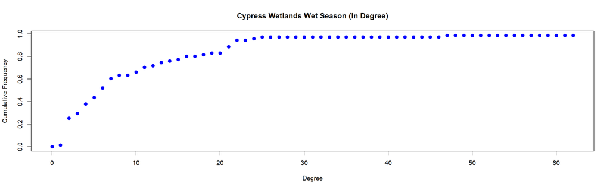

```r
Deg_Dist_Wet = degree_distribution(CypWet, cumulative=T, mode="in")

Plot4 = plot( x=0:max(cypWet_Degree), y=1-Deg_Dist_Wet, pch=19, cex=1.2, col="blue", main ="Cypress Wetlands Wet Season (In Degree)",
xlab="Degree", ylab="Cumulative Frequency")
```

Similarly, we will get the list of those animals for whom we see a change in degree during the dry and wet seasons.

```r
# Merge the in degree for wet and dry season together.

Df = cbind(cypWet_Degree , cypDry_Degree)

# Assign column names.
names(Df) = c("In Degree - In Season", "In Degree - Dry Season")

# Create one unique identifier.

Df$Identifier <- seq.int(nrow(Df))

# Extract only those rows where the degrees do not match in wet and dry season.

Df = Df[which(Df[,1]!=Df[,2])]

Df = cbind(vertex_attr(CypWet, name="vertex.names", index =Df$Identifier) , Df[,1], Df[,2])

names(Df) = c("Animals", "In Degree - Wet Season", "In Degree - Dry Season")

Df
```

```
##           Animals In Degree - Wet Season In Degree - Dry Season
##  1:    Alligators                     23                     22
##  2:        Snakes                     24                     27
##  3:   Salamanders                     10                      8
##  4: Kites & Hawks                     20                     21
##  5:        Egrets                     20                     17
##  6:    Wood stork                     20                     19
##  7:    White ibis                     15                     14
##  8:    Black Bear                      9                      8
##  9:       Raccoon                     15                     21
## 10:          Mink                     13                     15
## 11:        Bobcat                      7                      9
## 12:          Hogs                      6                      8
## 13:     Armadillo                      6                      8
```

We can clearly see that alligators are listed and this is mainly attributed to the fact that alligators are important animals. Alligators generally hibernate during the winter months and their metabolism rate decreases. As a result of that we can see a change in degress between the wet and the season.

#### Cypress Wetlands Dry & Wet Season Comparison - All Degree

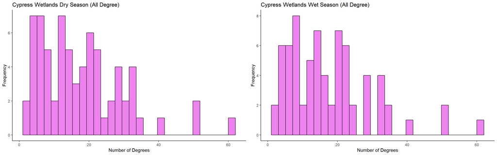

```r
# Calculate the out degree.

cypDry_Degree = as.data.table(degree(CypDry, mode = "all"))

cypWet_Degree = as.data.table(degree(CypWet, mode = "all"))

# Plot the degree distribution.

Plot1 = ggplot(data=cypDry_Degree, aes(cypDry_Degree$V1)) +
       geom_histogram(col = "black", fill= "violet") +
       theme_classic() +
       ggtitle("Cypress Wetlands Dry Season (All Degree)")  +
        xlab("Number of Degrees") +
        ylab("Frequency")

Plot2 = ggplot(data=cypWet_Degree, aes(cypWet_Degree$V1)) +
       geom_histogram(col = "black", fill= "violet") +
       theme_classic() +
       ggtitle("Cypress Wetlands Wet Season (All Degree)")  +
        xlab("Number of Degrees") +
        ylab("Frequency")

# Use the library fucntion grid arrange to compare the graphs side by side.

grid.arrange(Plot1, Plot2, nrow = 1)
```

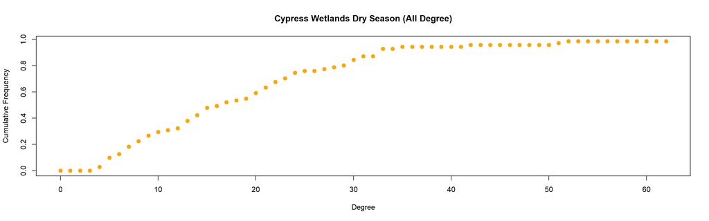

```r
# Lets also see how the cumulative distribution looks like.

Deg_Dist_Dry = degree_distribution(CypDry, cumulative=T, mode="all")

Plot3 = plot( x=0:max(cypDry_Degree), y=1-Deg_Dist_Dry, pch=19, cex=1.2, col="orange", main ="Cypress Wetlands Dry Season (All Degree)",
xlab="Degree", ylab="Cumulative Frequency")
```

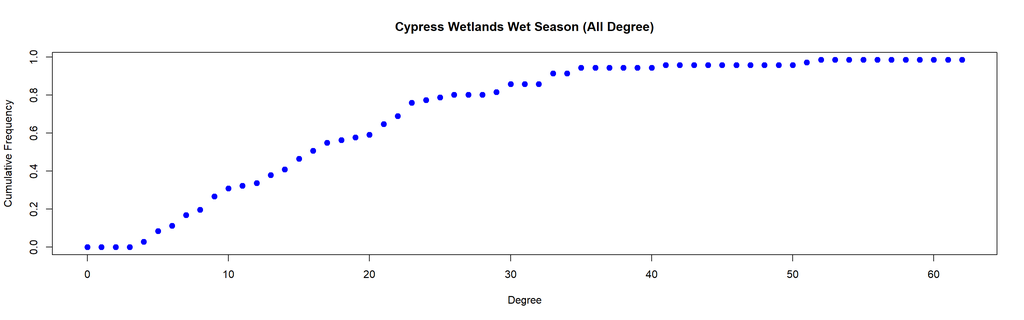

```r
Deg_Dist_Wet = degree_distribution(CypWet, cumulative=T, mode="all")

Plot4 = plot( x=0:max(cypWet_Degree), y=1-Deg_Dist_Wet, pch=19, cex=1.2, col="blue", main ="Cypress Wetlands Wet Season (All Degree)",
xlab="Degree", ylab="Cumulative Frequency")
```

From the above shown in and out degree tables we can clearly see that the degrees of alligators change between the wet and dry season. Based on that finding we decided to plot out only the alligators and their “neighbours”. By neighbours we mean those animals that are eaten by alligators and animals that eat alligators or their eggs. Undoubtedly, we expect to learn more about the reasons for the differences.

### Static Plot

```r
A = induced_subgraph(CypWet, c(23, neighbors(CypWet,23)))
B = induced_subgraph(CypDry, c(23, neighbors(CypDry,23)))

vertex_attr_names(A)
```

```
## [1] "bio.masses...cypwet.dat" "ECO.type"
## [3] "na"                      "vertex.names"
```

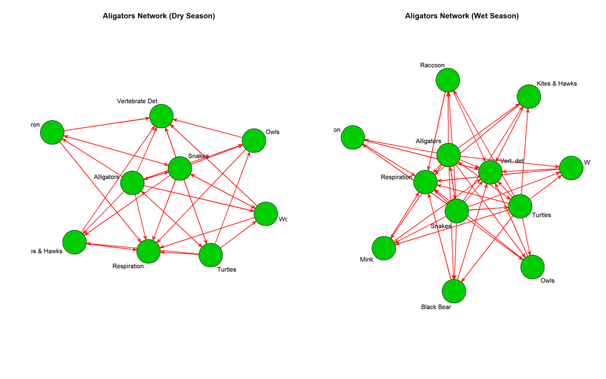

```r
# Change the type from igraph to network

A = asNetwork(A)
B = asNetwork(B)

# Plot the network diagram

par(mfrow=c(1,2))

plot.network(B , label = network.vertex.names(B) , vertex.col = 3, edge.col = "red", vertex.cex = 5 , main = "Aligators Network (Dry Season)")

plot.network(A , label = network.vertex.names(A) , vertex.col = 3, edge.col = "red", vertex.cex = 5 , main = "Aligators Network (Wet Season)")
```

### Arc Diagram

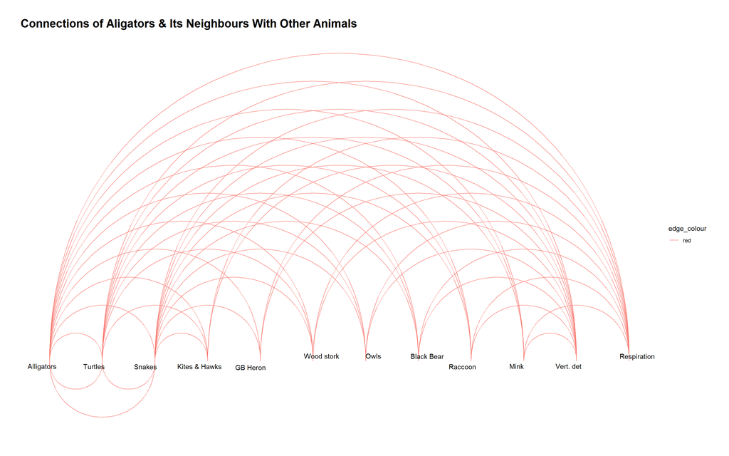

```r
A = asIgraph(A)
ggraph(A, layout = "linear") +
  geom_edge_arc(aes(col = "red"), alpha = 0.8 ) +
  scale_edge_width(range = c(0.2, 2)) +
  geom_node_text(aes(label = V(A)$vertex.names), repel = TRUE) +
  labs(edge_width = "Connections of Aligators & Its Neighbours With Other Animals") +
  theme_graph()+
  ggtitle("Connections of Aligators & Its Neighbours With Other Animals")
```

```r
  theme(legend.position = "bottom")
```

```
## List of 1
##  $ legend.position: chr "bottom"
##  - attr(*, "class")= chr [1:2] "theme" "gg"
##  - attr(*, "complete")= logi FALSE
##  - attr(*, "validate")= logi TRUE
```

The graph illustrates the importance of Vertebrate Det for alligators and many other animals. The connection between alligators and snakes shows that snakes eat alligator eggs and, alligators eat snakes and snake eggs. A similar pattern can be observed for turtles. We can conclude that controlling the population of snakes is key to control the population of alligators.

## Centrality Measure

In the next step we will extract a list of the top 10 animals based on the different centrality measures. This step will help us to define which animals eat many other kind of animals and which animals mainly serve as food for other animals.

### Out Degree Centrality - Dry Season

```r
# Calculate the out degree during the dry sesson

Cyp_Dry_Degree = data.table(degree(CypDry , mode = "out"))

# Creating a unique identifier.

Cyp_Dry_Degree$Identifier <- seq.int(nrow(Cyp_Dry_Degree))

# Ordering the data set in descending order based on out degree
setorder(Cyp_Dry_Degree, -V1)

# Extract top 20 page ids with highest out degree

TopAnimalsByOutDegree_Dry =Cyp_Dry_Degree[,][1:10]

# Get the name of the animals along with their biomass

TopAnimalsByOutDegree_Dry = data.table(cbind(vertex_attr(CypDry, name = "vertex.names",index =TopAnimalsByOutDegree_Dry$Identifier),
vertex_attr(CypDry, name = "bio.masses...cypdry.dat",index =TopAnimalsByOutDegree_Dry$Identifier), TopAnimalsByOutDegree_Dry$V1))

# Assign column names
names(TopAnimalsByOutDegree_Dry) = c("Animal","Biomass" , "Out Degree Value")

# Display the result

TopAnimalsByOutDegree_Dry
```

```
##                       Animal    Biomass Out Degree Value
##  1:       Ter. Invertebrates  0.6065807               40
##  2:    Aquatic Invertebrates  0.3096738               26
##  3:                    Prawn   1.150072               24
##  4:                 Crayfish    1.57471               23
##  5:              Apple Snail 0.07122805               23
##  6: Small Fish, herb + omniv  0.1164369               21
##  7: Small Fish, prim. carniv 0.01508307               20
##  8:                    Input          0               20
##  9:               Understory   47.35999               19
## 10:         Hardwoods Leaves   26.51985               19
```

### Out Degree Centrality - Wet Season

```r
# Calculate the out degree during the dry sesson

Cyp_Wet_Degree = data.table(degree(CypWet , mode = "out"))

# Creating a unique identifier

Cyp_Wet_Degree$Identifier <- seq.int(nrow(Cyp_Wet_Degree))

# Ordering the data set in descending order based on out degree
setorder(Cyp_Wet_Degree, -V1)

# Extract top 20 page ids with highest out degree

TopAnimalsByOutDegree_Wet =Cyp_Wet_Degree[,][1:10]

# Get the name of the animals along with their biomass

TopAnimalsByOutDegree_Wet = data.table(cbind(vertex_attr(CypDry, name = "vertex.names",index =TopAnimalsByOutDegree_Wet$Identifier),
vertex_attr(CypDry, name = "bio.masses...cypdry.dat",index =TopAnimalsByOutDegree_Wet$Identifier), TopAnimalsByOutDegree_Wet$V1))

# Assign column names
names(TopAnimalsByOutDegree_Wet) = c("Animal","Biomass" , "Out Degree Value")

# Display the result

TopAnimalsByOutDegree_Wet
```

```
##                       Animal    Biomass Out Degree Value
##  1:       Ter. Invertebrates  0.6065807               40
##  2:    Aquatic Invertebrates  0.3096738               26
##  3:                    Prawn   1.150072               24
##  4:                 Crayfish    1.57471               23
##  5:              Apple Snail 0.07122805               23
##  6: Small Fish, herb + omniv  0.1164369               21
##  7: Small Fish, prim. carniv 0.01508307               20
##  8:                    Input          0               20
##  9:               Understory   47.35999               19
## 10:         Hardwoods Leaves   26.51985               19
```

Central animals are those that have most out-links with other animals. Based on the above mentioned table we can conclude that Tertiary Invertebrates eat many different kind of other animals. This makes them less dependent on a single source of food. It deserves to mention that there are no significant differences between the dry and wet season in this case.

### In Degree Centrality - Dry Season

```r
# Calculate the in degree during the dry sesson

Cyp_Dry_Degree = data.table(degree(CypDry , mode = "in"))

# Creating a unique identifier.

Cyp_Dry_Degree$Identifier <- seq.int(nrow(Cyp_Dry_Degree))

# Ordering the data set in descending order based on in degree
setorder(Cyp_Dry_Degree, -V1)

# Extract top 20 page ids with highest in degree
# The top vertex with in degree is respiration. As it doesnot make sense to us we will exclude that. Probably a data entry error.As a result we will take the list from 2 to 11

TopAnimalsByInDegree_Dry =Cyp_Dry_Degree[,][2:11]

# Get the name of the animals along with their biomass

TopAnimalsByInDegree_Dry = data.table(cbind(vertex_attr(CypDry, name = "vertex.names",index =TopAnimalsByInDegree_Dry$Identifier),
vertex_attr(CypDry, name = "bio.masses...cypdry.dat",index =TopAnimalsByInDegree_Dry$Identifier), TopAnimalsByInDegree_Dry$V1))

# Assign column names
names(TopAnimalsByInDegree_Dry) = c("Animal","Biomass" , "In Degree Value")

# Display the result

TopAnimalsByInDegree_Dry
```

```
##              Animal      Biomass In Degree Value
##  1: Vertebrate Det.   0.06408651              46
##  2:          Snakes    0.1059386              27
##  3:      Alligators    0.1726627              22
##  4:         Turtles    0.1182843              21
##  5:   Kites & Hawks 0.0001129128              21
##  6:    Other herons  0.001882014              21
##  7:         Raccoon  0.005301335              21
##  8: Refractory Det.     302.1322              21
##  9:     Liable Det.     517.1664              21
## 10:            Owls 0.0001986624              20
```

### In Degree Centrality - Wet Season

```r
# Calculate the in degree during the dry sesson

Cyp_Wet_Degree = data.table(degree(CypWet , mode = "in"))

# Creating a unique identifier.

Cyp_Wet_Degree$Identifier <- seq.int(nrow(Cyp_Wet_Degree))

# Ordering the data set in descending order based on in degree
setorder(Cyp_Wet_Degree, -V1)

# Extract top 20 page ids with highest in degree
# The top vertex with in degree is respiration. As it doesnot make sense to us we will exclude that. Probably a data entry error.As a result we will take the list from 2 to 11

TopAnimalsByInDegree_Wet =Cyp_Wet_Degree[,][2:11]

# Get the name of the animals along with their biomass

TopAnimalsByInDegree_Wet = data.table(cbind(vertex_attr(CypDry, name = "vertex.names",index =TopAnimalsByInDegree_Wet$Identifier),
vertex_attr(CypDry, name = "bio.masses...cypdry.dat",index =TopAnimalsByInDegree_Wet$Identifier), TopAnimalsByInDegree_Wet$V1))

# Assign column names
names(TopAnimalsByInDegree_Wet) = c("Animal","Biomass" , "In Degree Value")

# Display the result

TopAnimalsByInDegree_Wet
```

```
##              Animal      Biomass In Degree Value
##  1: Vertebrate Det.   0.06408651              46
##  2:          Snakes    0.1059386              24
##  3:      Alligators    0.1726627              23
##  4:         Turtles    0.1182843              21
##  5:    Other herons  0.001882014              21
##  6: Refractory Det.     302.1322              21
##  7:     Liable Det.     517.1664              21
##  8:   Kites & Hawks 0.0001129128              20
##  9:          Egrets  0.001756378              20
## 10:      Wood stork  0.002251927              20
```

Based on the above mentioned table we can conclude that Vertebrate Det. serve as food for many different animals during the wet season as well as the dry season. The generally high values for turtles and alligators are probably a result of the fact that their eggs serve as food for other animals. Besides, young alligators and turtles also serve as food for many other animals throughout the year.

### All Degree Centrality - Dry Season

```r
# Calculate the all degree during the dry sesson.

Cyp_Dry_Degree = data.table(degree(CypDry , mode = "all"))

# Creating a unique identifier.

Cyp_Dry_Degree$Identifier <- seq.int(nrow(Cyp_Dry_Degree))

# Ordering the data set in descending order based on total degree
setorder(Cyp_Dry_Degree, -V1)

# Extract top 20 page ids with highest total degree
# The top vertex with in degree is respiration. As it doesnot make sense to us we will exclude that. Probably a data entry error.As a result we will take the list from 2 to 11

TopAnimalsByAllDegree_Dry =Cyp_Dry_Degree[,][2:11]

# Get the name of the animals along with their biomass

TopAnimalsByAllDegree_Dry = data.table(cbind(vertex_attr(CypDry, name = "vertex.names",index =TopAnimalsByAllDegree_Dry$Identifier),
vertex_attr(CypDry, name = "bio.masses...cypdry.dat",index =TopAnimalsByAllDegree_Dry$Identifier), TopAnimalsByAllDegree_Dry$V1))

# Assign column names
names(TopAnimalsByAllDegree_Dry) = c("Animal","Biomass" , "All Degree Value")

# Display the result

TopAnimalsByAllDegree_Dry
```

```
##                       Animal     Biomass All Degree Value
##  1:          Vertebrate Det.  0.06408651               51
##  2:       Ter. Invertebrates   0.6065807               50
##  3:                   Snakes   0.1059386               41
##  4: Small Fish, prim. carniv  0.01508307               34
##  5:    Aquatic Invertebrates   0.3096738               32
##  6: Small Fish, herb + omniv   0.1164369               32
##  7:             Other herons 0.001882014               32
##  8:              Liable Det.    517.1664               32
##  9:               Alligators   0.1726627               30
## 10:                  Turtles   0.1182843               30
```

### All Degree Centrality - Wet Season

```r
# Calculate the all degree during the dry sesson.

Cyp_Wet_Degree = data.table(degree(CypWet , mode = "all"))

# Creating a unique identifier.

Cyp_Wet_Degree$Identifier <- seq.int(nrow(Cyp_Wet_Degree))

# Ordering the data set in descending order based on total degree
setorder(Cyp_Wet_Degree, -V1)

# Extract top 20 page ids with highest total degree
# The top vertex with in degree is respiration. As it doesnot make sense to us we will exclude that. Probably a data entry error.As a result we will take the list from 2 to 11

TopAnimalsByAllDegree_Wet =Cyp_Wet_Degree[,][2:11]

# Get the name of the animals along with their biomass

TopAnimalsByAllDegree_Wet = data.table(cbind(vertex_attr(CypDry, name = "vertex.names",index =TopAnimalsByAllDegree_Wet$Identifier),
vertex_attr(CypDry, name = "bio.masses...cypdry.dat",index =TopAnimalsByAllDegree_Wet$Identifier), TopAnimalsByAllDegree_Wet$V1))

# Assign column names
names(TopAnimalsByAllDegree_Wet) = c("Animal","Biomass" , "All Degree Value")

# Display the result

TopAnimalsByAllDegree_Wet
```

```
##                       Animal    Biomass All Degree Value
##  1:          Vertebrate Det. 0.06408651               51
##  2:       Ter. Invertebrates  0.6065807               50
##  3:                   Snakes  0.1059386               40
##  4: Small Fish, prim. carniv 0.01508307               34
##  5:               Alligators  0.1726627               34
##  6:    Aquatic Invertebrates  0.3096738               32
##  7: Small Fish, herb + omniv  0.1164369               32
##  8:                  Turtles  0.1182843               32
##  9:              Liable Det.   517.1664               32
## 10:                 Crayfish    1.57471               29
```

An overall high degree centrality indicates that an animal not only serves as food for other animals but also eats many other animals. Vertebrate Det. score very high on this dimension in both seasons. The high value of snakes can be attributed to the circumstance that their eggs and young snakes are eaten by many other animals throughout the year. A similar phenomena is shown for alligators. The unusual high change in the seasons for “Other herons” can be attributed to their travel patterns. For example, harons often leave cold places and move to warmer places to breed. Obviously, this pattern can lead to an increase in degrees in the dry season.

### Betweeness Centrality - Dry Season

```r
# Calculate the betweenness during the dry sesson

Cyp_Dry_Betweenness = data.table(betweenness(CypDry, directed = T))

# Creating a unique identifier.

Cyp_Dry_Betweenness$Identifier <- seq.int(nrow(Cyp_Dry_Betweenness))

# Ordering the data set in descending order based on degree
setorder(Cyp_Dry_Betweenness, -V1)

# Extract top 20 page ids with highest betweenness

TopAnimalsByBetweeness_Dry =Cyp_Dry_Betweenness[,][1:10]

# Get the name of the animals along with their biomass

TopAnimalsByBetweeness_Dry = data.table(cbind(vertex_attr(CypDry, name = "vertex.names",index =TopAnimalsByBetweeness_Dry$Identifier),
vertex_attr(CypDry, name = "bio.masses...cypdry.dat",index =TopAnimalsByBetweeness_Dry$Identifier), TopAnimalsByBetweeness_Dry$V1))

# Assign column names
names(TopAnimalsByBetweeness_Dry) = c("Animal","Biomass" , "Betweeneess Value")

# Display the result

TopAnimalsByBetweeness_Dry
```

```
##                       Animal      Biomass Betweeneess Value
##  1:          Vertebrate Det.   0.06408651  1882.76612428634
##  2:       Ter. Invertebrates    0.6065807  1583.19313556916
##  3:              Liable Det.     517.1664  488.755005045519
##  4:          Refractory Det.     302.1322  300.695073132766
##  5:                   Snakes    0.1059386  138.273619177386
##  6:    Aquatic Invertebrates    0.3096738  97.4292946018103
##  7:             Other herons  0.001882014  64.0955970395056
##  8: Small Fish, prim. carniv   0.01508307  62.6798380808584
##  9: Small Fish, herb + omniv    0.1164369   62.252810036439
## 10:                     Mink 0.0001387758  37.1333618218957
```

### Betweeness Centrality - Wet Season

```r
# Calculate the betweenness during the dry sesson

Cyp_Wet_Betweenness = data.table(betweenness(CypWet, directed = T))

# Creating a unique identifier.

Cyp_Wet_Betweenness$Identifier <- seq.int(nrow(Cyp_Wet_Betweenness))

# Ordering the data set in descending order based on degree
setorder(Cyp_Wet_Betweenness, -V1)

# Extract top 20 page ids with highest betweenness

TopAnimalsByBetweeness_Wet =Cyp_Wet_Betweenness[,][1:10]

# Get the name of the animals along with their biomass

TopAnimalsByBetweeness_Wet = data.table(cbind(vertex_attr(CypDry, name = "vertex.names",index =TopAnimalsByBetweeness_Wet$Identifier),
vertex_attr(CypDry, name = "bio.masses...cypdry.dat",index =TopAnimalsByBetweeness_Wet$Identifier), TopAnimalsByBetweeness_Wet$V1))

# Assign column names
names(TopAnimalsByBetweeness_Wet) = c("Animal","Biomass" , "Betweeneess Value")

# Display the result

TopAnimalsByBetweeness_Wet
```

```
##                       Animal     Biomass Betweeneess Value
##  1:          Vertebrate Det.  0.06408651  1960.04289196311
##  2:       Ter. Invertebrates   0.6065807  1672.26592345499
##  3:              Liable Det.    517.1664  495.657064528174
##  4:          Refractory Det.    302.1322  307.206685273805
##  5:                   Snakes   0.1059386  115.170788828191
##  6:    Aquatic Invertebrates   0.3096738  96.4887128546926
##  7: Small Fish, prim. carniv  0.01508307  57.2314947953135
##  8: Small Fish, herb + omniv   0.1164369  56.8044667508941
##  9:               White ibis 0.001960033  50.7632179179989
## 10:               Alligators   0.1726627  47.3764424229626
```

The betweeness centrality plays a crucial rule. For example, in this case a high betweeness centrality indicates the importance of an animal within its network. A high degree of betweeness means that an animal eats another animal and in turn is eaten by other animals. In short we can say that these animals help to maintain the stability of the ecosystem. If that animal goes extinct than this can have serious imlications on the network/underlying ecosystem. The very high value for Vertebrate Det. in both seasons illustrates its importance for the underlying network. The size of an animal does not determine the importance for its network but the betweeness centrality does.

### Eigen Vector Centrality - Dry Season

```r
# Calculate the eigen vector during the dry sesson.

Cyp_Dry_Eigen = eigen_centrality(CypDry, directed = T)
Cyp_Dry_Eigen = data.table(Cyp_Dry_Eigen$vector)

# Creating a unique identifier.

Cyp_Dry_Eigen$Identifier <- seq.int(nrow(Cyp_Dry_Eigen))

# Ordering the data set in descending order based on eigen vector
setorder(Cyp_Dry_Eigen, -V1)

# Extract top 20 page ids with highest eigen vector

TopAnimalsByEigen_Dry =Cyp_Dry_Eigen[,][2:11]

# Get the name of the animals along with their biomass

TopAnimalsByEigen_Dry = data.table(cbind(vertex_attr(CypDry, name = "vertex.names",index =TopAnimalsByEigen_Dry$Identifier),
vertex_attr(CypDry, name = "bio.masses...cypdry.dat",index =TopAnimalsByEigen_Dry$Identifier), TopAnimalsByEigen_Dry$V1))

# Assign column names
names(TopAnimalsByEigen_Dry) = c("Animal","Biomass" , "Eigen Centrality Value")

# Display the result

TopAnimalsByEigen_Dry
```

```
##               Animal      Biomass Eigen Centrality Value
##  1:  Vertebrate Det.   0.06408651      0.926954915191195
##  2:           Snakes    0.1059386      0.435015536165388
##  3:       Alligators    0.1726627      0.379655977020452
##  4:    Kites & Hawks 0.0001129128      0.369067257592683
##  5:             Owls 0.0001986624      0.361043083025239
##  6:          Raccoon  0.005301335      0.339789294575899
##  7:       Wood stork  0.002251927      0.318889209965365
##  8:           G. Fox  0.000880464      0.283838821466655
##  9:          Turtles    0.1182843      0.283268853802827
## 10: Great blue heron 0.0003478197      0.278753375874863
```

### Eigen Vector Centrality - Wet Season

```r
# Calculate the eigen vector during the dry sesson.

Cyp_Wet_Eigen = eigen_centrality(CypWet, directed = T)
Cyp_Wet_Eigen = data.table(Cyp_Wet_Eigen$vector)

# Creating a unique identifier.

Cyp_Wet_Eigen$Identifier <- seq.int(nrow(Cyp_Wet_Eigen))

# Ordering the data set in descending order based on eigen vector
setorder(Cyp_Wet_Eigen, -V1)

# Extract top 20 page ids with highest eigen vector

TopAnimalsByEigen_Wet =Cyp_Wet_Eigen[,][2:11]

# Get the name of the animals along with their biomass

TopAnimalsByEigen_Wet = data.table(cbind(vertex_attr(CypDry, name = "vertex.names",index =TopAnimalsByEigen_Wet$Identifier),
vertex_attr(CypDry, name = "bio.masses...cypdry.dat",index =TopAnimalsByEigen_Wet$Identifier), TopAnimalsByEigen_Wet$V1))

# Assign column names
names(TopAnimalsByEigen_Wet) = c("Animal","Biomass" , "Eigen Centrality Value")

# Display the result

TopAnimalsByEigen_Wet
```

```
##               Animal      Biomass Eigen Centrality Value
##  1:  Vertebrate Det.   0.06408651       0.91917456387575
##  2:       Alligators    0.1726627      0.367988830906813
##  3:             Owls 0.0001986624       0.34508029432422
##  4:    Kites & Hawks 0.0001129128       0.34508029432422
##  5:           Snakes    0.1059386      0.342227602548276
##  6:       Wood stork  0.002251927      0.330065325924529
##  7:          Turtles    0.1182843      0.298345578054016
##  8:          Raccoon  0.005301335      0.291951403970018
##  9: Great blue heron 0.0003478197      0.286484689571252
## 10:             Mink 0.0001387758      0.273456328413462
```

Eigenvector centrality generalizes degree centrality by incorporating the importance of the neighbors. This helps us to determine the “most important” animals for the network. The seasonsal changes could be a result of the breeding activities of relevant animals such as snakes and alligators. Nevertheless, Vertebrate Det is once again on top of the list. The consecutive top-ranking exemplifies its importance for the entire ecosystem. The high-ranking of alligators justifies our previous decision to conduct an in-depth evaluation of alligators.

### Closeness Centrality - Dry Season

```r
# Calculate the closeness during the dry sesson

Cyp_Dry_Closeness = data.table(closeness(CypDry))
# Creating a unique identifier.

Cyp_Dry_Closeness$Identifier <- seq.int(nrow(Cyp_Dry_Closeness))

# Ordering the data set in descending order based on closeness
setorder(Cyp_Dry_Closeness, -V1)

# Extract top 20 page ids with highest closeness

TopAnimalsByCloseness_Dry =Cyp_Dry_Closeness[,][1:10]

# Get the name of the animals along with their biomass

TopAnimalsByCloseness_Dry = data.table(cbind(vertex_attr(CypDry, name = "vertex.names",index =TopAnimalsByCloseness_Dry$Identifier),
vertex_attr(CypDry, name = "bio.masses...cypdry.dat",index =TopAnimalsByCloseness_Dry$Identifier), TopAnimalsByCloseness_Dry$V1))

# Assign column names.
names(TopAnimalsByCloseness_Dry) = c("Animal","Biomass" , "Closeness Value")

# Display the result

TopAnimalsByCloseness_Dry
```

```
##                    Animal   Biomass      Closeness Value
##  1:                 Input         0  0.00735294117647059
##  2:            Understory  47.35999  0.00105042016806723
##  3:      Hardwoods Leaves  26.51985  0.00105042016806723
##  4:           Vine Leaves 0.3429814 0.000904977375565611
##  5:        Cypress Leaves  15.37547 0.000904977375565611
##  6:          Cypress Wood  10693.75 0.000848176420695505
##  7:               HW Wood  800.9207 0.000848176420695505
##  8:                 Roots  469.4484 0.000848176420695505
##  9: Periphyton/Macroalgae  110.4234 0.000846740050804403
## 10:         Phytoplankton  0.111162 0.000846023688663283
```

### Closeness Centrality - Wet Season

```r
# Calculate the closeness during the dry sesson

Cyp_Wet_Closeness = data.table(closeness(CypWet))
# Creating a unique identifier.

Cyp_Wet_Closeness$Identifier <- seq.int(nrow(Cyp_Wet_Closeness))

# Ordering the data set in descending order based on closeness
setorder(Cyp_Wet_Closeness, -V1)

# Extract top 20 page ids with highest closeness

TopAnimalsByCloseness_Wet =Cyp_Wet_Closeness[,][1:10]

# Get the name of the animals along with their biomass

TopAnimalsByCloseness_Wet = data.table(cbind(vertex_attr(CypDry, name = "vertex.names",index =TopAnimalsByCloseness_Wet$Identifier),
vertex_attr(CypDry, name = "bio.masses...cypdry.dat",index =TopAnimalsByCloseness_Wet$Identifier), TopAnimalsByCloseness_Wet$V1))

# Assign column names.
names(TopAnimalsByCloseness_Wet) = c("Animal","Biomass" , "Closeness Value")

# Display the result

TopAnimalsByCloseness_Wet
```

```
##                    Animal   Biomass      Closeness Value
##  1:                 Input         0  0.00719424460431655
##  2:            Understory  47.35999  0.00105042016806723
##  3:      Hardwoods Leaves  26.51985  0.00105042016806723
##  4:           Vine Leaves 0.3429814 0.000904977375565611
##  5:        Cypress Leaves  15.37547 0.000904977375565611
##  6:          Cypress Wood  10693.75 0.000848176420695505
##  7:               HW Wood  800.9207 0.000848176420695505
##  8:                 Roots  469.4484 0.000848176420695505
##  9: Periphyton/Macroalgae  110.4234 0.000846023688663283
## 10:         Phytoplankton  0.111162  0.00084530853761623
```

In a connected graph, closeness centrality (or closeness) of a node is a measure of centrality in a network, calculated as the sum of the length of the shortest paths between the node and all other nodes in the graph. Thus the more central a node is, the closer it is to all other nodes. In other words we could say how easily an animal can interact with other animals in the network. We can only observe minor changes at the top of the list. Our findings support our previous findings and are in line with you expectations.

### Alpha Centrality - Dry Season

```r
# Calculate the alpha centrality during the dry sesson

Cyp_Dry_Alpha = data.table(alpha_centrality(CypDry))

# Creating a unique identifier.

Cyp_Dry_Alpha$Identifier <- seq.int(nrow(Cyp_Dry_Alpha))

# Ordering the data set in descending order based on alpha centrality
setorder(Cyp_Dry_Alpha, -V1)

# Extract top 20 page ids with highest alpha centrality

TopAnimalsByAlpha_Dry =Cyp_Dry_Alpha[,][1:10]

# Get the name of the animals along with their biomass

TopAnimalsByAlpha_Dry = data.table(cbind(vertex_attr(CypDry, name = "vertex.names",index =TopAnimalsByAlpha_Dry$Identifier),
vertex_attr(CypDry, name = "bio.masses...cypdry.dat",index =TopAnimalsByAlpha_Dry$Identifier), TopAnimalsByAlpha_Dry$V1))

# Assign column names.
names(TopAnimalsByAlpha_Dry) = c("Animal","Biomass" , "Alpha Centrality Value")

# Display the result

TopAnimalsByAlpha_Dry
```

```
##                  Animal      Biomass Alpha Centrality Value
##  1:              Bobcat 0.0001228952       523.032762691854
##  2:              G. Fox  0.000880464        276.85064935065
##  3:        Other herons  0.001882014       244.333530106258
##  4:         Mice & Rats 4.982359e-05       157.240554899646
##  5: Passeriformes pred. 2.631779e-05       155.240554899646
##  6:              Shrews 8.346792e-06       154.240554899646
##  7:                Owls 0.0001986624       150.886953955136
##  8:       Kites & Hawks 0.0001129128       140.614226682409
##  9:              Egrets  0.001756378       47.4687131050769
## 10:             Turtles    0.1182843       44.6242621015348
```

### Alpha Centrality - Wet Season

```r
# Calculate the alpha centrality during the dry sesson

Cyp_Dry_Wet = data.table(alpha_centrality(CypWet))

# Creating a unique identifier.

Cyp_Dry_Wet$Identifier <- seq.int(nrow(Cyp_Dry_Wet))

# Ordering the data set in descending order based on alpha centrality
setorder(Cyp_Dry_Wet, -V1)

# Extract top 20 page ids with highest alpha centrality

TopAnimalsByAlpha_Wet =Cyp_Dry_Wet[,][1:10]

# Get the name of the animals along with their biomass

TopAnimalsByAlpha_Wet = data.table(cbind(vertex_attr(CypDry, name = "vertex.names",index =TopAnimalsByAlpha_Wet$Identifier),
vertex_attr(CypDry, name = "bio.masses...cypdry.dat",index =TopAnimalsByAlpha_Wet$Identifier), TopAnimalsByAlpha_Wet$V1))

# Assign column names.
names(TopAnimalsByAlpha_Wet) = c("Animal","Biomass" , "Alpha Centrality Value")

# Display the result

TopAnimalsByAlpha_Wet
```

```
##                  Animal      Biomass Alpha Centrality Value
##  1:              G. Fox  0.000880464       371.833232992175
##  2:              Bobcat 0.0001228952       164.632149307647
##  3:        Other herons  0.001882014       145.545454545455
##  4:              Egrets  0.001756378       135.428657435281
##  5:         Mice & Rats 4.982359e-05       72.3160746538233
##  6: Passeriformes pred. 2.631779e-05       70.3160746538234
##  7:              Shrews 8.346792e-06       69.3160746538234
##  8:          Wood stork  0.002251927       20.5972305839855
##  9:             Turtles    0.1182843       10.1167971101745
## 10:           Squirrels   0.00115359       9.00000000000002
```

Alpha centrality is a measure of centrality of nodes within a graph. It is an adaptation of eigenvector centrality with the addition that nodes are imbued with importance from external sources.

### Page Rank Centrality - Dry Season

```r
# Calculate the page rank centrality during the dry sesson

Cyp_Dry_PR = data.table(unlist(page_rank(CypDry, directed = T)))

# Creating a unique identifier.

Cyp_Dry_PR$Identifier <- seq.int(nrow(Cyp_Dry_PR))

# Ordering the data set in descending order based on degree
setorder(Cyp_Dry_PR, -V1)

# Extract top 20 page ids with highest page rank centrality

TopAnimalsByPageRank_Dry =Cyp_Dry_PR[,][3:12]

# Get the name of the animals along with their biomass

TopAnimalsByPageRank_Dry = data.table(cbind(vertex_attr(CypDry, name = "vertex.names",index =TopAnimalsByPageRank_Dry$Identifier),
vertex_attr(CypDry, name = "bio.masses...cypdry.dat",index =TopAnimalsByPageRank_Dry$Identifier), TopAnimalsByPageRank_Dry$V1))

# Assign column names.
names(TopAnimalsByPageRank_Dry) = c("Animal","Biomass" , "Page Rank Centrality Value")

# Display the result

TopAnimalsByPageRank_Dry
```

```
##                 Animal     Biomass Page Rank Centrality Value
##  1:    Vertebrate Det.  0.06408651          0.122362521802517
##  2: Ter. Invertebrates   0.6065807         0.0362365118672272
##  3:        Liable Det.    517.1664         0.0357173051793936
##  4:    Refractory Det.    302.1322         0.0357173051793936
##  5:            Opossum 0.007554747         0.0257314030971676
##  6:             Snakes   0.1059386         0.0254211624015956
##  7:           Vultures 0.002297464         0.0246064751605993
##  8:             G. Fox 0.000880464         0.0211333174668408
##  9:            Raccoon 0.005301335         0.0202039493163923
## 10:         Alligators   0.1726627         0.0195265779943955
```

### Page Rank Centrality - Wet Season

```r
# Calculate the page rank centrality during the dry sesson

Cyp_Wet_PR = data.table(unlist(page_rank(CypWet, directed = T)))

# Creating a unique identifier.

Cyp_Wet_PR$Identifier <- seq.int(nrow(Cyp_Wet_PR))

# Ordering the data set in descending order based on degree
setorder(Cyp_Wet_PR, -V1)

# Extract top 20 page ids with highest page rank centrality

TopAnimalsByPageRank_Wet =Cyp_Wet_PR[,][3:12]

# Get the name of the animals along with their biomass

TopAnimalsByPageRank_Wet = data.table(cbind(vertex_attr(CypDry, name = "vertex.names",index =TopAnimalsByPageRank_Wet$Identifier),
vertex_attr(CypDry, name = "bio.masses...cypdry.dat",index =TopAnimalsByPageRank_Wet$Identifier), TopAnimalsByPageRank_Wet$V1))

# Assign column names.
names(TopAnimalsByPageRank_Wet) = c("Animal","Biomass" , "Page Rank Centrality Value")

# Display the result

TopAnimalsByPageRank_Wet
```

```
##                       Animal     Biomass Page Rank Centrality Value
##  1:          Vertebrate Det.  0.06408651          0.127118021858701
##  2:       Ter. Invertebrates   0.6065807         0.0373897639704615
##  3:          Refractory Det.    302.1322         0.0368045553386916
##  4:              Liable Det.    517.1664         0.0368045553386916
##  5:                   G. Fox 0.000880464         0.0280392805013513
##  6:                  Opossum 0.007554747         0.0266324010403455
##  7:                 Vultures 0.002297464         0.0254771600565241
##  8:                   Snakes   0.1059386         0.0208497239526341
##  9:               Alligators   0.1726627         0.0203971278316066
## 10: Small Fish, prim. carniv  0.01508307         0.0169143057515345
```

The key takeway from Page Rank Centrality is the following: An animal is important if it is pointed to by other important animals. As excpected, Vertebrate Det is once again on the top of the list. The differences between the wet and dry season can be attributed to the weather and the breeding habits. For example, Raccoons only appear on the Dry Season list. In general this can give as a good overview regarding the sensibility of an underlying ecosystem. For instance, massive changes in the population of Vertebrate Det can cause disbalances in the ecosystem. This knowledge helps to control and ensure the well-being of the ecosystem.

## Shiny App - Putting It All Together

In order to provide the Centrality measures found above in an interactive way we will create a shiny app which will provide the centrality measures in a tabular format based on interactivity. This option helps our stakeholders to have a closer look at animals and their roles. This app will provide our stakeholders with “detail on demand” which will ultimately translate into concrete actions to combat overpopulation.

This is the interactive map which will not work in the static version of the html file that has been uploaded. In order to use the filters interactively, please run the entire scripts in the local machine.

```r
# Data preparation which will be supplied to the shiny server

setnames(TopAnimalsByOutDegree_Dry, old = "Out Degree Value", new = "Value")
TopAnimalsByOutDegree_Dry$Measure = "Out Degree"
TopAnimalsByOutDegree_Dry$Season = "Dry"

setnames(TopAnimalsByInDegree_Dry, old = "In Degree Value", new = "Value")
TopAnimalsByInDegree_Dry$Measure = "In Degree"
TopAnimalsByInDegree_Dry$Season = "Dry"

setnames(TopAnimalsByAllDegree_Dry, old = "All Degree Value", new = "Value")
TopAnimalsByAllDegree_Dry$Measure = "All Degree"
TopAnimalsByAllDegree_Dry$Season = "Dry"

setnames(TopAnimalsByBetweeness_Dry, old = "Betweeneess Value", new = "Value")
TopAnimalsByBetweeness_Dry$Measure = "Betweeness"
TopAnimalsByBetweeness_Dry$Season  = "Dry"

setnames(TopAnimalsByEigen_Dry, old = "Eigen Centrality Value", new = "Value")
TopAnimalsByEigen_Dry$Measure = "Eigen Centrality"
TopAnimalsByEigen_Dry$Season  = "Dry"

setnames(TopAnimalsByCloseness_Dry, old = "Closeness Value", new = "Value")
TopAnimalsByCloseness_Dry$Measure = "Closeness"
TopAnimalsByCloseness_Dry$Season  = "Dry"

setnames(TopAnimalsByAlpha_Dry, old = "Alpha Centrality Value", new = "Value")
TopAnimalsByAlpha_Dry$Measure = "Alpha Centrality"
TopAnimalsByAlpha_Dry$Season  = "Dry"

setnames(TopAnimalsByPageRank_Dry, old = "Page Rank Centrality Value", new = "Value")
TopAnimalsByPageRank_Dry$Measure = "Page Rank Centrality"
TopAnimalsByPageRank_Dry$Season  = "Dry"

setnames(TopAnimalsByOutDegree_Wet, old = "Out Degree Value", new = "Value")
TopAnimalsByOutDegree_Wet$Measure = "Out Degree"
TopAnimalsByOutDegree_Wet$Season = "Wet"

setnames(TopAnimalsByInDegree_Wet, old = "In Degree Value", new = "Value")
TopAnimalsByInDegree_Wet$Measure = "In Degree"
TopAnimalsByInDegree_Wet$Season = "Wet"

setnames(TopAnimalsByAllDegree_Wet, old = "All Degree Value", new = "Value")
TopAnimalsByAllDegree_Wet$Measure = "All Degree"
TopAnimalsByAllDegree_Wet$Season = "Wet"

setnames(TopAnimalsByBetweeness_Wet, old = "Betweeneess Value", new = "Value")
TopAnimalsByBetweeness_Wet$Measure = "Betweeness"
TopAnimalsByBetweeness_Wet$Season  = "Wet"

setnames(TopAnimalsByEigen_Wet, old = "Eigen Centrality Value", new = "Value")
TopAnimalsByEigen_Wet$Measure = "Eigen Centrality"
TopAnimalsByEigen_Wet$Season  = "Wet"

setnames(TopAnimalsByCloseness_Wet, old = "Closeness Value", new = "Value")
TopAnimalsByCloseness_Wet$Measure = "Closeness"
TopAnimalsByCloseness_Wet$Season  = "Wet"

setnames(TopAnimalsByAlpha_Wet, old = "Alpha Centrality Value", new = "Value")
TopAnimalsByAlpha_Wet$Measure = "Alpha Centrality"
TopAnimalsByAlpha_Wet$Season  = "Wet"

setnames(TopAnimalsByPageRank_Wet, old = "Page Rank Centrality Value", new = "Value")
TopAnimalsByPageRank_Wet$Measure = "Page Rank Centrality"
TopAnimalsByPageRank_Wet$Season  = "Wet"

# Merge all the dataset

Df= rbind(TopAnimalsByOutDegree_Dry,TopAnimalsByInDegree_Dry,TopAnimalsByAlpha_Dry, TopAnimalsByEigen_Dry,TopAnimalsByPageRank_Dry, TopAnimalsByAllDegree_Dry,TopAnimalsByBetweeness_Dry , TopAnimalsByCloseness_Dry,TopAnimalsByOutDegree_Wet,TopAnimalsByInDegree_Wet,TopAnimalsByAlpha_Wet, TopAnimalsByEigen_Wet,TopAnimalsByPageRank_Wet, TopAnimalsByAllDegree_Wet,TopAnimalsByBetweeness_Wet , TopAnimalsByCloseness_Wet)

# Define the user interface

ui = fluidPage(
  titlePanel("This is an Interactive Shiny App"),
  sidebarLayout(
    sidebarPanel(
      selectInput("Measure", "Select the Type of Centrality Measure", choices = Df$Measure , selected = 2),
      selectInput("Season", "Select the Type of Season", choices = Df$Season, selected =2)
    ),
  mainPanel("Here is the Required Data", style = "font-size:120%; width:50%",
    tableOutput("Df")
  )
  )
)


# Define the server logic

server = function(input, output) {
  output$Df = renderTable({
    MeasureFilter = subset(Df, Df$Measure == input$Measure & Df$Season ==input$Season)
  })

  }

# Run the application
shinyApp(ui = ui, server = server)
```

Shiny applications not supported in static R Markdown documents

## Transitivity & Reciprocity

The basic concept of transitivity is when “a friend of my friend is my friend”. Applied to our case we can say that “the food of my food regards me as food”. We will now compare the global and local clustering coefficients between the Dry and Wet seasons in south Florida.

```r
# Global transitivity

transitivity(graph = CypDry , type= "global")
```

```
## [1] 0.4047812
```

```r
transitivity(graph = CypWet , type= "global")
```

```
## [1] 0.3955183
```

```r
# local transitivity

transitivity(graph = CypDry , type= "localaverage")
```

```
## [1] 0.4994948
```

```r
transitivity(graph = CypWet , type= "localaverage")
```

```
## [1] 0.5003582
```

Although there is not much difference between the global and local clustering coefficent value in the dry and wet seasons, it can be inferred that the Dry seasons have a slightly greater “global clustering coefficient” than the Wet seasons. Nevertheless, the “local clustering coefficient” is less. Since the values for transitivity range around 0.5 we can conclude that we are dealing with a non-random network. Undoubtedly, this finding is important for our stakeholders because it helps to generalize findings.

```r
reciprocity(graph = CypDry , mode= "ratio")
```

```
## [1] 0.03559871
```

```r
reciprocity(graph = CypWet , mode= "ratio")
```

```
## [1] 0.03104575
```

```r
reciprocity(graph = CypDry , mode= "default")
```

```
## [1] 0.06875
```

```r
reciprocity(graph = CypWet , mode= "default")
```

```
## [1] 0.06022187
```

## Network Modelling

### Erdos Reyni Model (Random Network)

We will build the Erdos Reyni Model, with the same proportion as we have in the original model. In this excercise we will only compare the “in degree” between the original with the Erdos Reyni Model.

```r
# Lets first calculate the proportion of vertices and edges in the original graph


proportion = vcount(CypDry) / ecount(CypDry)

proportion
```

```
## [1] 0.1109375
```

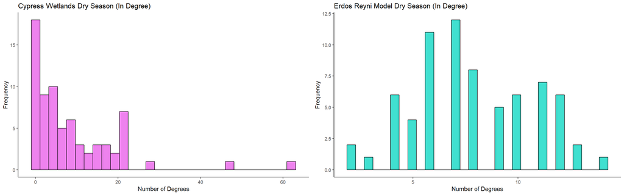

```r
# Calculate Erdos Reyni model

Dry_ER = erdos.renyi.game(n= vcount(CypDry), directed = T, loops = F, p.or.m = proportion)

# Histogram of the plot and comparing it with original model

Plot1 = ggplot(data=as.data.table(degree(CypDry, mode= "in")), aes(as.data.table(degree(CypDry, mode= "in"))$V1)) +
       geom_histogram(col = "black", fill= "violet") +
       theme_classic() +
       ggtitle("Cypress Wetlands Dry Season (In Degree)")  +
        xlab("Number of Degrees") +
        ylab("Frequency")

Plot2 = ggplot(data=as.data.table(degree(Dry_ER, mode= "in")),            aes(as.data.table(degree(Dry_ER, mode= "in"))$V1)) +
       geom_histogram(col = "black", fill= "turquoise") +
       theme_classic() +
       ggtitle("Erdos Reyni Model Dry Season (In Degree)")  +
        xlab("Number of Degrees") +
        ylab("Frequency")

# Use the library fucntion grid arrange to compare the graphs side by side.

grid.arrange(Plot1, Plot2, nrow = 1)
```

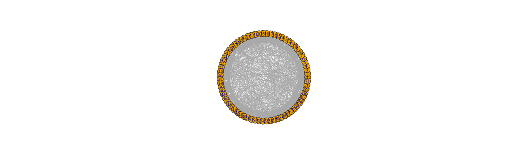

```r
# Plot the Erdos Renyi Model

plot(Dry_ER, layout=layout.circle)
```

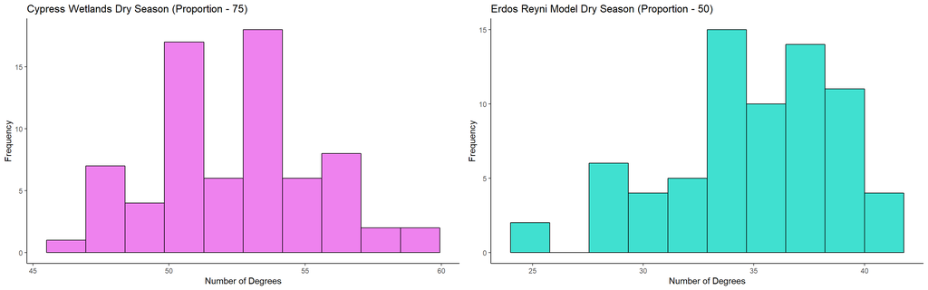

```r
# Increase the proportion and compare how the Erdos Reyni model looks like

Dry_ER_75 = erdos.renyi.game(n= vcount(CypDry), directed = T, loops = F, p.or.m = .75)

Dry_ER_50 = erdos.renyi.game(n= vcount(CypDry), directed = T, loops = F, p.or.m = .50)

# Histogram of the plot and comparing it with original model

Plot3 = ggplot(data=as.data.table(degree(Dry_ER_75, mode= "in")), aes(as.data.table(degree(Dry_ER_75, mode= "in"))$V1)) +
       geom_histogram(col = "black", fill= "violet" , bins = 10) +
       theme_classic() +
       ggtitle("Cypress Wetlands Dry Season (Proportion - 75)")  +
        xlab("Number of Degrees") +
        ylab("Frequency")

Plot4 = ggplot(data=as.data.table(degree(Dry_ER_50, mode= "in")),            aes(as.data.table(degree(Dry_ER_50, mode= "in"))$V1)) +
       geom_histogram(col = "black", fill= "turquoise" ,bins =10) +
       theme_classic() +
       ggtitle("Erdos Reyni Model Dry Season (Proportion - 50)")  +
        xlab("Number of Degrees") +
        ylab("Frequency")

# Use the library fucntion grid arrange to compare the graphs side by side.

grid.arrange(Plot3, Plot4, nrow = 1)
```

The study of random networks reached prominence thanks to the fundamental work of Pál Erdos and Alfréd Rényi. Undoubtedly, our findings support the assumption that the newtork is not random.

## Watts Strogatz Model (Small World Network)

We will now create another network model using the watts strogatz game. The probability will be the same as the proportion of the original graph and we will use total number of vertices in the original graph as the size.

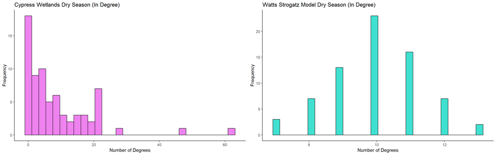

```r
Dry_WS = watts.strogatz.game(dim = 1,size =vcount(CypDry),nei = 5, p = proportion)

# Histogram of the plot and comparing it with original model

Plot5 = ggplot(data=as.data.table(degree(CypDry, mode= "in")), aes(as.data.table(degree(CypDry, mode= "in"))$V1)) +
       geom_histogram(col = "black", fill= "violet") +
       theme_classic() +
       ggtitle("Cypress Wetlands Dry Season (In Degree)")  +
        xlab("Number of Degrees") +
        ylab("Frequency")

Plot6 = ggplot(data=as.data.table(degree(Dry_WS, mode= "in")),            aes(as.data.table(degree(Dry_WS, mode= "in"))$V1)) +
       geom_histogram(col = "black", fill= "turquoise") +
       theme_classic() +
       ggtitle("Watts Strogatz Model Dry Season (In Degree)")  +
        xlab("Number of Degrees") +
        ylab("Frequency")

# Use the library fucntion grid arrange to compare the graphs side by side.

grid.arrange(Plot5, Plot6, nrow = 1)
```

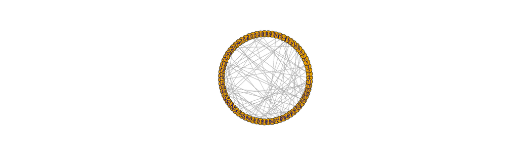

```r
# Plot the Watts Strogatz Model

plot(Dry_WS, layout=layout.circle)
```

## Comparison Erdos Reyni VS Watts Strogatz Model

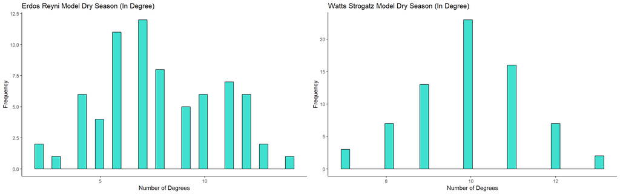

```r
# Lets startup by ploting the distribution of both the models

grid.arrange(Plot2 , Plot6 , nrow = 1)
```

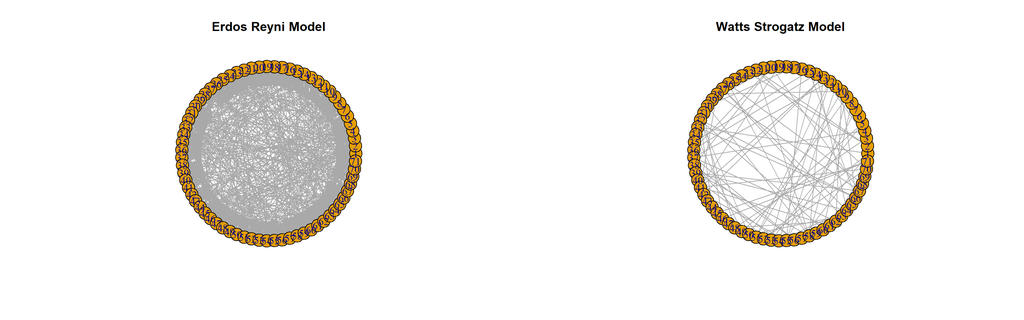

```r
# Compare the plot

par(mfrow=c(1,2))


plot(Dry_ER, layout=layout.circle , main = "Erdos Reyni Model")

plot(Dry_WS, layout=layout.circle, main = "Watts Strogatz Model")
```

```r
# Average path length value

AvgPath = cbind("Average Path length", average.path.length(Dry_ER), average.path.length(Dry_WS))

# Diameter value

Dia = cbind("Diameter", diameter(Dry_ER), diameter(Dry_WS))

# Global transitivity

GTrans = cbind("Global Transitivity", transitivity(Dry_ER , type ="global"), transitivity(Dry_WS , type="global"))

# local transitivity

LTrans = cbind("Local Transitivity", transitivity(Dry_ER , type ="localaverage"), transitivity(Dry_WS , type="localaverage"))


# Mean in degree

MeanInDeg = cbind("Mean In Degree", mean(degree(Dry_ER , mode="in")), mean(degree(Dry_WS, mode= "in")))


# Mean out degree

MeanOutDeg = cbind("Mean Out Degree", mean(degree(Dry_ER , mode="out")), mean(degree(Dry_WS, mode= "out")))

# Median in degree

MedianInDeg = cbind("Median In Degree", median(degree(Dry_ER , mode="in")), median(degree(Dry_WS, mode= "in")))


# Median out degree

MedianOutDeg = cbind("Median Out Degree", median(degree(Dry_ER , mode="out")), median(degree(Dry_WS, mode= "out")))

# Standard deviation of in degree

SdInDeg = cbind("Standard deviation In Degree", sd(degree(Dry_ER , mode="in")), sd(degree(Dry_WS, mode= "in")))


# Standard deviation out degree

SdOutDeg = cbind("Standard deviation Out Degree", sd(degree(Dry_ER , mode="out")), sd(degree(Dry_WS, mode= "out")))


ComparisionTable = as.data.table(rbind(MeanInDeg,MeanOutDeg,MedianInDeg,MedianOutDeg,SdInDeg,SdOutDeg, Dia,AvgPath,GTrans,LTrans))

# Assigning column names

names(ComparisionTable) = c("Measures","ER Model Value" , "WS Model Value")
```

### Model Comparison Table

```r
# Display result

ComparisionTable
```

```
##                          Measures    ER Model Value    WS Model Value
##  1:                Mean In Degree  7.87323943661972                10
##  2:               Mean Out Degree  7.87323943661972                10
##  3:              Median In Degree                 7                10
##  4:             Median Out Degree                 8                10
##  5:  Standard deviation In Degree  2.82301549747676  1.36277028773849
##  6: Standard deviation Out Degree  2.90285365737524  1.36277028773849
##  7:                      Diameter                 4                 4
##  8:           Average Path length  2.28772635814889  2.23822937625755
##  9:           Global Transitivity 0.229263395658175 0.334049079754601
## 10:            Local Transitivity 0.230668459878901 0.351002596777245
```

## Power Law

Let us now see if the degree distribution of the Erdos Reyni model or the Watts Strogatz model follow a power law. To check the power law we will work only with the “in degree” centrality.

```r
# Plot the degree distribution of the WS model

Deg_Dist_Dry_WS= degree_distribution(Dry_WS, cumulative=T, mode="in")

probability = Deg_Dist_Dry_WS[-1]

# Delete blank values


nonzero.position= which(probability != 0)
probability = probability[nonzero.position]
degree = 1:max(degree(Dry_WS))
degree = degree[nonzero.position]

# Fit of degree distribution

reg= lm(log(probability) ~ log(degree))
summary(reg)$r.square
```

```
## [1] 0.3040147
```

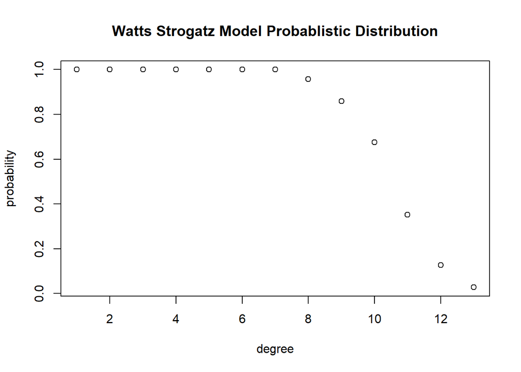

```r
cozf= coef(reg)

# Plot the distribution


plot(probability ~degree , main ="Watts Strogatz Model Probablistic Distribution")
```

```r
# Plot the degree distribution of the WS model

Deg_Dist_Dry_ER= degree_distribution(Dry_ER, cumulative=T, mode="in")

probability = Deg_Dist_Dry_ER[-1]

# Delete blank values


nonzero.position= which(probability != 0)
probability = probability[nonzero.position]
degree = 1:max(degree(Dry_ER))
degree = degree[nonzero.position]

# Fit of degree distribution

reg= lm(log(probability) ~ log(degree))
summary(reg)$r.square
```

```
## [1] 0.515219
```

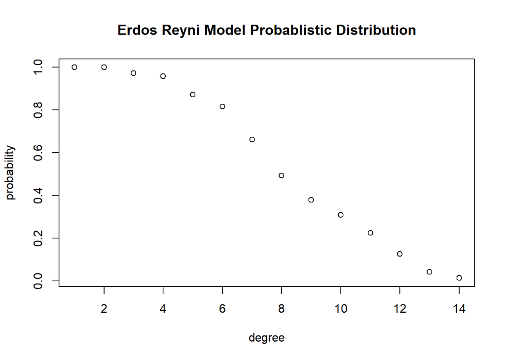

```r
cozf= coef(reg)

# Plot the distribution


plot(probability ~degree , main ="Erdos Reyni Model Probablistic Distribution")
```

## Community Detection

We want to cluster the animals into different communities so that we can tackle a problem from a community perspective and not an individual one. Community detection is crucial in order to understand the interaction between various clusters. We explored various algortihms (shown below) to determine the right amount of communities. The filter option helps our stakeholders to select the community of interest in a fast and efficient manner.

### Algorithm : Walk trap

```r
# Subset the dataset

Animals = induced_subgraph(CypWet, c(1:66))

# Run clustering with walk trap algorithm

WT = walktrap.community(Animals, modularity=TRUE, steps =7)

# Assign the communities to the members

V(Animals)$community <- WT$membership

# Modularity of the algorithm

modularity(WT)
```

```
## [1] 0.1991999
```

```r
# Prepare the edges for the visualization

nodes <- data.frame(id = V(Animals)$vertex.names, title = V(Animals)$vertex.names, group = V(Animals)$community)
nodes <- nodes[order(nodes$id, decreasing = F),]
nodes$A = seq(nrow(nodes))

# Prepare the edges for the visualization

edges <- get.data.frame(Animals, what="edges")[1:2]
edges$from =nodes$id[match(edges$from,nodes$A)]
edges$to =nodes$id[match(edges$to,nodes$A)]

# Display the visualization

visNetwork(nodes, edges , main ="Communiuty Detection Using Walk Trap") %>%
  visOptions(highlightNearest = TRUE, nodesIdSelection = TRUE) %>%
  visGroups(groupname = "A", color = "red", shape = "triangle")
```

[interactive chart not shown]

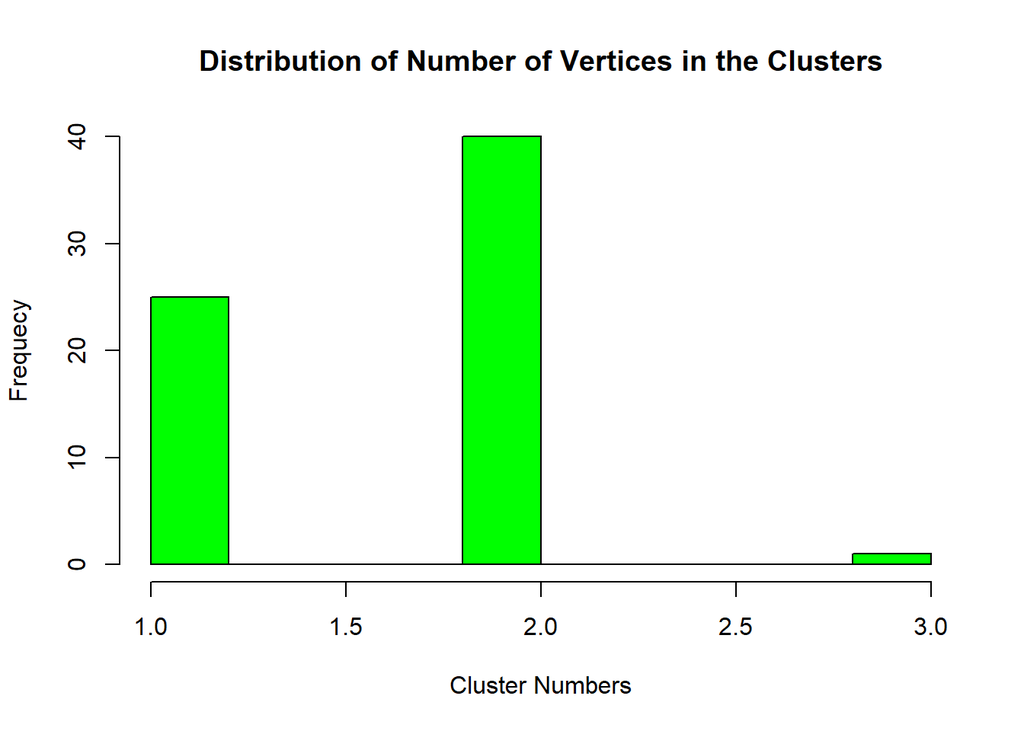

```r
# Lets check the distribution of the number of vertices in the group

hist(WT$membership , col = "green"
     , main = "Distribution of Number of Vertices in the Clusters"
     , xlab = "Cluster Numbers"
     , ylab = "Frequecy" , breaks  =9)
```

```r
# Get the absolute number

table(WT$membership)
```

```
##
##  1  2  3
## 25 40  1
```

#### Modularity Optimization

Changing the hyper parameters increases or decreases the modularity. Depending upon wheter you want randomness or not you can choose any one of the following hyperparameters. Let us compare the walk trap with different random walks.

```r
set.seed(6497)

Iter1 = modularity(walktrap.community(Animals, modularity=TRUE, steps =2))

Iter2 = modularity(walktrap.community(Animals, modularity=TRUE, steps =3))

Iter3 = modularity(walktrap.community(Animals, modularity=TRUE, steps =4))

Iter4 = modularity(walktrap.community(Animals, modularity=TRUE, steps =5))

Iter5 = modularity(walktrap.community(Animals, modularity=TRUE, steps =6))

Iter6 = modularity(walktrap.community(Animals, modularity=TRUE, steps =7))

Iter7 = modularity(walktrap.community(Animals, modularity=TRUE, steps =8))

# Display the modularity of the various iterations

cbind(Iter1,Iter2,Iter3,Iter4,Iter5,Iter6, Iter7)
```

```
##          Iter1     Iter2     Iter3     Iter4     Iter5     Iter6     Iter7
## [1,] 0.1844491 0.1895965 0.1991999 0.1991999 0.2049717 0.1991999 0.1984021
```

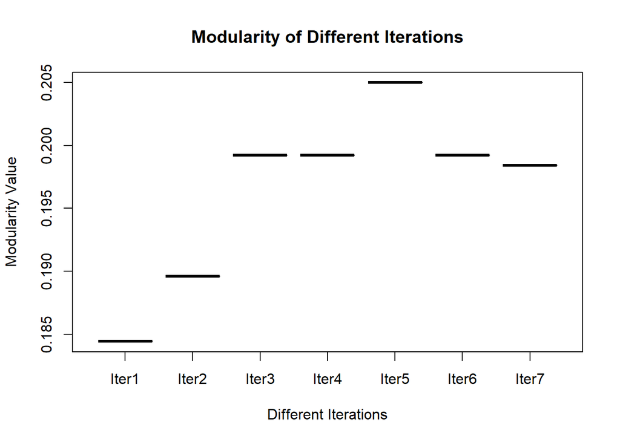

```r
Df = melt(cbind(Iter1,Iter2,Iter3,Iter4,Iter5,Iter6, Iter7))

# Modularity Optimization

plot(x=Df$Var2,y= Df$value , main="Modularity of Different Iterations"
     , ylab= "Modularity Value"
     , xlab="Different Iterations")
```

The above shown graph helps us to determine the right parameter to get a high or low modularity.

It can be inferred that Iteration 1 with random walks of value 2 provides the lowest modurality, whereas the iteration 5 with a random walk of 6 provides the highest modularity.

```r
# Subset the dataset

Animals = induced_subgraph(CypWet, c(1:66))

# Run clustering with walk trap algorithm

IM = cluster_infomap(Animals)

# Assign the communities to the members

V(Animals)$community <- IM$membership

# Modularity of the algorithm

modularity(IM)
```

```
## [1] 0
```

```r
# Prepare the edges for the visualization

nodes <- data.frame(id = V(Animals)$vertex.names, title = V(Animals)$vertex.names, group = V(Animals)$community)
nodes <- nodes[order(nodes$id, decreasing = F),]
nodes$A = seq(nrow(nodes))

# Prepare the edges for the visualization

edges <- get.data.frame(Animals, what="edges")[1:2]
edges$from =nodes$id[match(edges$from,nodes$A)]
edges$to =nodes$id[match(edges$to,nodes$A)]

# Display the visualization

visNetwork(nodes, edges , main ="Communiuty Detection Using Walk Trap") %>%
  visOptions(highlightNearest = TRUE, nodesIdSelection = TRUE) %>%
  visGroups(groupname = "A", color = "red", shape = "triangle")
```

[interactive chart not shown]

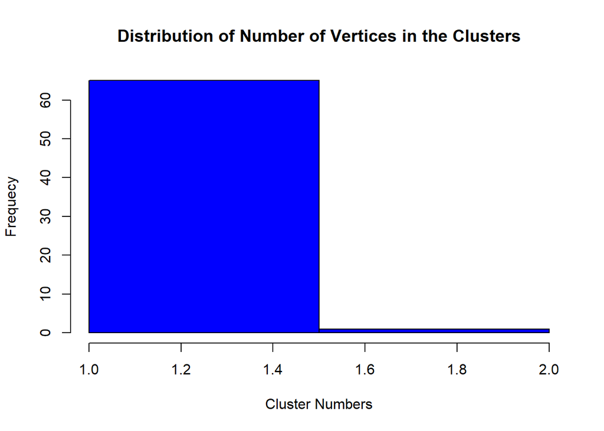

```r
# Lets check the distribution of the number of vertices in the group

hist(IM$membership , col = "blue"
     , main = "Distribution of Number of Vertices in the Clusters"
     , xlab = "Cluster Numbers"
     , ylab = "Frequecy" , breaks  =3)
```

```r
# Get the absolute number

table(IM$membership)
```

```
##
##  1  2
## 65  1
```

Unfortunately, this algorithm does not perform that well, as it clusters almost all the animals in one cluster and only one animal in the other cluster. This does not provide any meaningful insights for our stakeholders.

## Conclusion

The objective of our analysis was to provide insights for our stakeholders (e.g. governments, NGOs, etc.) so that they can streamline their activites. Based on that we created a kind of interactive tool to extract meaningful insights. We want to provide this tool to our target audience so they can use it in their daily work and update it with the latest datasets. Undoubtedly, further information in the data-set could have helped us to further comment on information diffusion. Nevertheless, the limited information on that topic made it challenging to extract meaningful insights. Our work will help our stakeholders to take faster and more customized actions in regards to endangered species, overpooulation of animals and the spead of animal diseases. Global warming forces us to take action in these areas and our work is a contribution to our obligations.